# IODS course project

#### **Question II: Performing PCA on non-standardized dataset**

First we perform the PCA analysis using the original (non-standardized) dataset. PCA biplots are frequently used to show the component scores and variable loading. The bottom axis represents the PC1 scores, while the left, top and left axes depict the PC2 scores, loading on PC1, and loading on PC2, respectively. The scores depict the observations in two dimensions, while the vectors show the original dimensions and their relationship with respect to each other and other PCs. Further the vectors are from the PC origin, the more the standard deviation of the feature is. Also, the angle between the vectors (including each variable and a PC axis) reveals information on correlation between the variables. If the angle between the vectors is small, their corresponding variables are highly correlated. If the angle is close to 90 degree, it implies that there is no correlation between the variables, while the angle close to 180 degrees shows a negative correlation. Since the highly correlated variables might be traced back to the same underlying component, they can be reduced to principle components.

```
## [1] "sdev"     "rotation" "center"   "scale"    "x"
```

```
## Standard deviations (1, .., p=8):
## [1] 1.854416e+04 1.855219e+02 2.518701e+01 1.145441e+01 3.766241e+00
## [6] 1.565912e+00 1.912052e-01 1.591112e-01
##
## Rotation (n x k) = (8 x 8):
##                     PC1           PC2           PC3           PC4
## Edu2.FM   -5.607472e-06  0.0006713951 -3.412027e-05 -2.736326e-04
## Labo.FM    2.331945e-07 -0.0002819357  5.302884e-04 -4.692578e-03
## Edu.Exp   -9.562910e-05  0.0075529759  1.427664e-02 -3.313505e-02
## Life.Exp  -2.815823e-04  0.0283150248  1.294971e-02 -6.752684e-02
## GNI       -9.999832e-01 -0.0057723054 -5.156742e-04  4.932889e-05
## Mat.Mor    5.655734e-03 -0.9916320120  1.260302e-01 -6.100534e-03
## Ado.Birth  1.233961e-03 -0.1255502723 -9.918113e-01  5.301595e-03
## Parli.F   -5.526460e-05  0.0032317269 -7.398331e-03 -9.971232e-01
##                     PC5           PC6           PC7           PC8
## Edu2.FM   -0.0022935252  2.180183e-02  6.998623e-01  7.139410e-01
## Labo.FM    0.0022190154  3.264423e-02  7.132267e-01 -7.001533e-01
## Edu.Exp    0.1431180282  9.882477e-01 -3.826887e-02  7.776451e-03
## Life.Exp   0.9865644425 -1.453515e-01  5.380452e-03  2.281723e-03
## GNI       -0.0001135863 -2.711698e-05 -8.075191e-07 -1.176762e-06
## Mat.Mor    0.0266373214  1.695203e-03  1.355518e-04  8.371934e-04
## Ado.Birth  0.0188618600  1.273198e-02 -8.641234e-05 -1.707885e-04
## Parli.F   -0.0716401914 -2.309896e-02 -2.642548e-03  2.680113e-03
```

```
## PC1 PC2 PC3 PC4 PC5 PC6 PC7 PC8
## 100   0   0   0   0   0   0   0
```

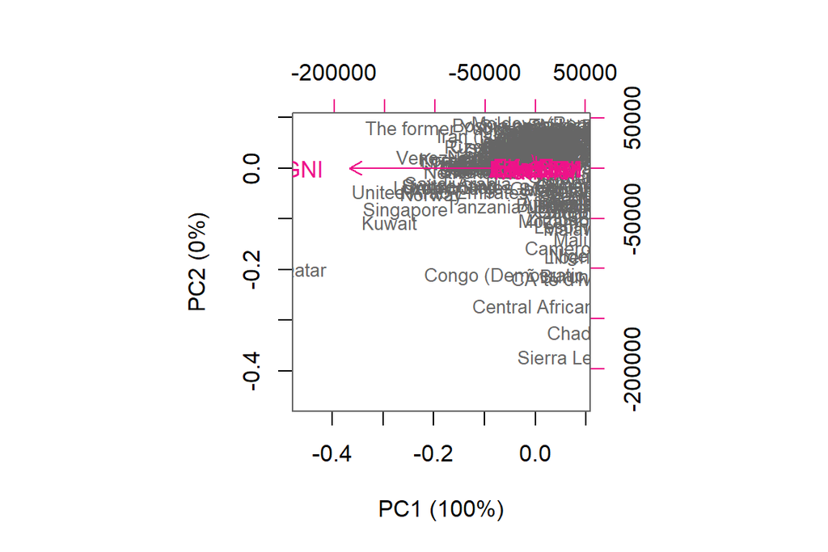

#### **Question III: Performing PCA on standardized dataset**

PCA is performed to reduce dimension and this is performed via identifying the principle components. Based on PCA, the vectors (directions) with the largest variances are the features with the highest importance. Hence, if there are various variables with various variance, PCA loads on the ones with the largest variance. Furthermore, in dataset like the human dataset, the variables have been measured in different scales. Thereby, to avoid the output being affected by these issues and make the variables comparable, standardization is an essential step to be taken prior to applying to PCA. For instance, we can see from the figures that the PCA on the non-standardized dataset gives the loading on one variable.

```
##  PC1  PC2  PC3  PC4  PC5  PC6  PC7  PC8
## 53.6 16.2  9.6  7.6  5.5  3.6  2.6  1.3
```

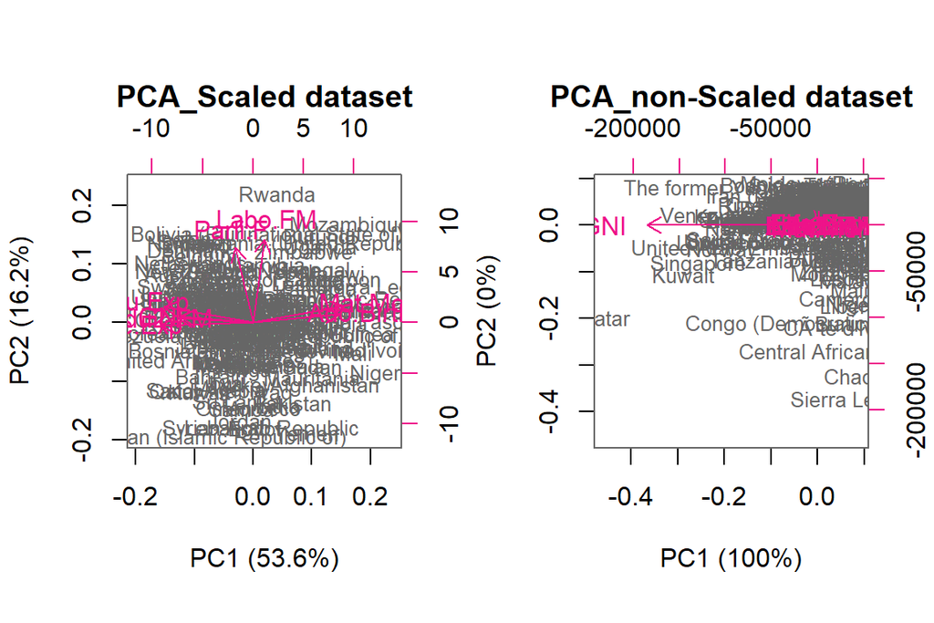

#### **Question IV: Interpretation of the PCA**

Having the following variables in the dataset, we can see that there are some countries having higher rate of each of these variables. Those variables along the first PC (horizontal line) makes up the 53.6 % of the data and those along the second PC (vertical line) makes up 16.2 % of it.

“Country” = Country name “GNI” = Gross National Income per capita “Life.Exp” = Life expectancy at birth “Edu.Exp” = Expected years of schooling “Mat.Mor” = Maternal mortality ratio “Ado.Birth” = Adolescent birth rate “Parli.F” = Percetange of female representatives in parliament “Edu2.F” = Proportion of females with at least secondary education “Edu2.M” = Proportion of males with at least secondary education “Labo.F” = Proportion of females in the labour force “Labo.M” " Proportion of males in the labour force “Edu2.FM” = Edu2.F / Edu2.M “Labo.FM” = Labo2.F / Labo2.M

Along the second PC, the countries towrds the positive side have higher percentage of female representatives in parliament and higher ratio of proportion of females to males in labour force.